# Sensibilité environnementale et dépenses publiques en faveur de l’environnement

Quentin Merrien, Catherine Berleur et Françoise Berleur

13/04/2021

Pour rappel : v7 : Tout bien considéré, diriez-vous que vous êtes… (p.3 de ZA7500_q_fr.pdf) 1 – Très heureux 2 – Assez heureux 3 – Pas très heureux 4 – Pas heureux du tout

à finir. Je le ferais.

Point d’analyse intéressant : une fois les paramètres économétriques estimés, on peut essayer d’expliquer/interpréter les situations contrefactuelles, c’est-à-dire celles qui s’éloignent le plus de l’estimation.

Mayda et Rodrik (2005) font une étude économétrique à partir de la WVS, voir p’tet leur méthode.

Trouver des indicateurs environnementaux supplémentaires : https://www.ecosia.org/search?q=indicators+of+environmental+awareness+data+base&addon=chrome&addonversion=3.3.0&method=topbar http://jultika.oulu.fi/files/nbnfioulu-201312142043.pdf https://www.oecd.org/env/indicators-modelling-outlooks/data-and-indicators.htm

### I. Mise en perspective introductive dans le contexte économique et social.

Le 9 mai dernier, des marches pour le climat eurent lieu dans toute la France, afin d’infléchir la loi « Climat et résilience » qui vient d’être vôtée par les députés. Ces mobilisations en faveur du climat ont-elles une influence sur la politique écologique et environnementale des gouvernements ?

Notre sujet de recherche vise à contribuer à cette vaste question, en se focalisant sur le lien entre ce que l’on a appelé sensibilité environnementale et les dépenses publiques de protection de l’environnement. Les difficultés de mesure statistique concernant les mobilisations environnementales nous ont en effet poussé à choisir comme proxy la sensibilité environnementale.

Cette contribution s’inscrit dans lignée de la sociologie de l’action publique. En particulier, l’article fondateur de Felstiner & alli (1981) sur l’émergence des problèmes publics peut servir de cadre analytique. Les auteurs y définissent trois conditions d’apparition d’un problème public : naming, blaming, claiming. L’étape du naming conduit à une transformation de l’ordre symbolique, et impose une nouvelle manière de voir les choses : la sensibilité publique envers certaines questions participe à l’établissement de mise à l’agenda de problèmes publics. Ainsi, une sensibilité environnementale plus importante conduirait à un cadrage différent des problèmes environnementaux, et serait nécessaire aux autres conditions de l’émergence de l’action environnementale et écologique comme problème public.

### II. Formulation d’un problème économétrique.

Le premier enjeu de notre démarche économétrique se situe dans le choix des variables expliquées et explicatives. Pour étudier l’effet de la sensibilité environnementale sur les dépenses de protection de l’environnement, la variable dépendante retenue est la *NEEP* (dépenses nationales pour la protection de l’environnement) dans l’UE et ses États membres. Cette mesure, définie par Eurostat, permet d’apprécier les ressources que consacrent les unités résidents à la protection de l’environnement naturel au cours d’une période donnée. Elles sont calculées comme étant la somme des dépenses courantes consacrées aux activités de protection de l’environnement et des investissements destinés aux activités de protection de l’environnement, y compris les transferts nets vers le reste du monde.

Il s’agit ensuite de définir ce qu’est la sensibilité environnementale afin de construire un jeu de variables à même de la refléter. Dès lors, on retiendra l’acception suivante : la sensibilité environnementale correspond à l’importance attachée aux problèmes environnementaux et aux enjeux écologiques. Dès lors, elle comprend la perception de la gravité des problèmes environnementaux, le degré de connaissance des problèmes environnementaux, et le soutien aux dépenses gouvernementales pour la protection de l’environnement [Thiery-Seror, 1996][^1] La difficulté réside alors en la traduction de ces éléments en une variable économétrique. Pour construire cette première variable explicative, nous avons croisé plusieurs bases de données : l’Environmental Awareness Index (EAI)[^2] et l’European Values Study (EVS) de 2017. L’*EAI* dispose en effet de variables permettant d’apprécier la sensibilisation des citoyens aux questions écologiques, que l’on peut assimiler au degré de connaissance des problèmes environnementaux. L’EVS permet elle de couvrir les deux autres dimensions de la sensibilité environnementale. Les variables *env1* à *env5* rendent compte de la perception des problèmes environnementaux des personnes sondées. La variable *env6* témoigne du soutien aux mesures gouvernementales pour la défense de l’environnement. Afin de construire une variable explicative agrégée pour la sensibilité environnementale (*sensi_env*), on pondère les variables des ces trois facteurs par 1/3. Les autres variables explicatives, que l’on pourra appeler variables de contrôle, sont au nombre de 4. Il paraît raisonnable de penser que les dépenses environnementales d’un pays sont liées à son niveau de développement économique, conformément à la thèse avancée par R. Inglehart dans **La Révolution silencieuse** (1977). Pour exprimer l’influence du niveau de développement économique d’un pays sur sa NEEP, nous avons retenu le revenu médian (*rev_med*) établi par Eurostat dans l’enquête EU-SILC. Il est aussi possible de considérer que les inégalités intra-pays influencent ces dépenses. D’une part, une inégalité, lorsqu’elle est rendue publique, réduit la contribution à un bien public de tous les participants [Anderson et al., 2008]. Puisqu’il est possible de considérer l’environnement comme un bien public (non-rival et non-exclusif), il apparaît pertinent de prendre en compte les inégalités dans notre modèle économétrique. De plus, les sociétés inégalitaires auraient plus de mal à mener les réformes nécessaires pour surmonter un choc externe [Rodrik, 1999]. Nous avons donc retenu le coefficient de Gini (indicateur synthétique de mesure des inégalités et de la redistribution très utilisé au niveau international) comme variable explicative. Les deux dernières variables de contrôle sont l’Environmental Performance Index (*EPI*) qui permet d’évaluer la performance environnementale d’un pays ainsi que le pourcentage de personnes de 15 à 64 disposant d’un diplôme d’enseignement supérieur pour rendre compte du niveau d’éducation.

### III. Présentation des bases de données et statistiques descriptives.

### IV. Proposition et justification de différents modèles linéaires.

### V. Comparaison des coefficients et de la significativité des modèles.

### VI. Interprétation et proposition de pistes de réflexion complémentaires (limites blabla).

Limite : le questionnaire EVS ne propose pas beaucoup de questions relatives à l’environnement, et celles-ci sont formuléees de manière non neutre, ce qui peut induire un biais dans les questions. Parler de deux des problèmes (environnement v. emploi et “m’en balec”) L’International Social Survey Programme conduit une enquête par questionnaire parmi les 42 pays membres du programme, sur le thème de l’environnement. Le questionnaire final est disponible ici[^3] mais les résultats ne sont pas encore publiés. Au vu des questions posées par le questionnaire, introduire des variables qui en proviennent permettrait de limiter les biais relatifs à la formulation des questions (cf. la question 6 : how concerned are you about environmental issues?) et d’affiner l’analyse.

## Régression linéaire

```
## Analysis of Variance Table
##
## Response: depenses_brutes_env
##           Df     Sum Sq   Mean Sq F value Pr(>F)
## sensi_env  1  123541345 123541345   0.417 0.5266
## Residuals 18 5333059742 296281097
```

```
## Analysis of Variance Table
##
## Model 1: depenses_brutes_env ~ sensi_env
## Model 2: depenses_brutes_env ~ soutien_pol_env
##   Res.Df        RSS Df Sum of Sq F Pr(>F)
## 1     18 5333059742
## 2     18 5376074482  0 -43014741
```

```
##
## Call:
## lm(formula = depenses_brutes_env ~ sensi_env + EPI.new + REV_MED_EURO_2017 +
##     EDUC_SUP_2017 + GINI_2017, data = base_complete)
##
## Residuals:
##    Min     1Q Median     3Q    Max
## -16485  -8774  -2202   4627  45586
##
## Coefficients:
##                     Estimate Std. Error t value Pr(>|t|)
## (Intercept)       -1.042e+05  9.823e+04  -1.061   0.3066
## sensi_env         -3.363e+02  6.926e+02  -0.486   0.6348
## EPI.new            1.969e+03  1.102e+03   1.787   0.0956 .
## REV_MED_EURO_2017 -1.612e-01  7.498e-01  -0.215   0.8329
## EDUC_SUP_2017     -8.910e+02  6.906e+02  -1.290   0.2178
## GINI_2017          7.983e+02  1.114e+03   0.716   0.4855
## ---
## Signif. codes:  0 '***' 0.001 '**' 0.01 '*' 0.05 '.' 0.1 ' ' 1
##
## Residual standard error: 16130 on 14 degrees of freedom
## Multiple R-squared:  0.3325, Adjusted R-squared:  0.09406
## F-statistic: 1.395 on 5 and 14 DF,  p-value: 0.2853
```

```
##           1           2           3           4           5           6
##  -1063.3916  -9219.4973  -3449.4381  52922.3150  -9385.8848 -12183.0284
##           7           8           9          10          11          12
##   6602.1810 -10339.4821  32091.6132  -8818.4126  18402.8802  -5794.3736
##          13          14          15          16          17          18
##   6003.4267  -7913.5757   -373.1596  -8993.6756  -7474.5635  -8936.8660
##          19          20
## -13068.5435  -9008.5237
```

```
##         1         2         3         4         5         6         7         8
## 12383.892  9901.397 14766.638 14132.685 15262.585 12638.228 10382.819 14180.482
##         9        10        11        12        13        14        15        16
## 10793.187 10906.813 11497.720  6384.574 11932.173 12962.676  9038.860 11283.076
##        17        18        19        20
##  9580.063 17655.366 13926.644 10528.624
```

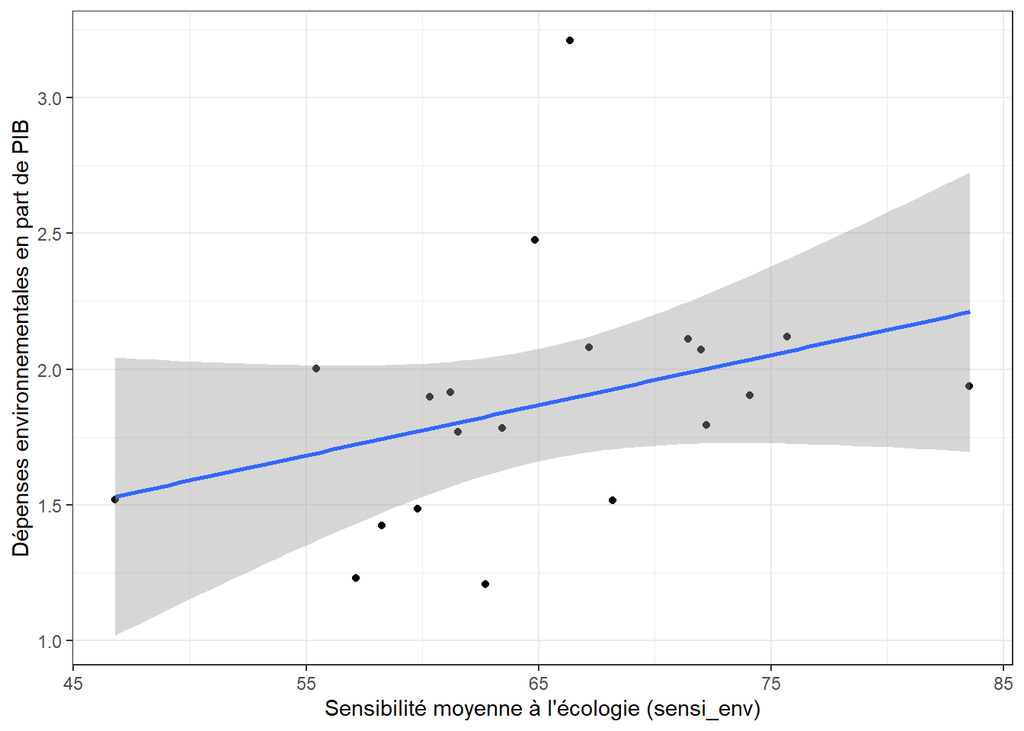

|  | *Dependent variable:* |  |  |
| --- | --- | --- | --- |
|  | depenses_brutes_env |  |  |
|  | (1) | (2) | (3) |
| sensi_env | 306.553 |  | -336.305 |
|  | (474.735) |  | (692.576) |
| soutien_pol_env |  | 175.132 |  |
|  |  | (337.282) |  |
| EPI.new |  |  | 1,969.223* |
|  |  |  | (1,102.069) |
| REV_MED_EURO_2017 |  |  | -0.161 |
|  |  |  | (0.750) |
| EDUC_SUP_2017 |  |  | -891.047 |
|  |  |  | (690.563) |
| GINI_2017 |  |  | 798.316 |
|  |  |  | (1,114.194) |
| Constant | -7,957.756 | 449.012 | -104,242.900 |
|  | (31,156.420) | (22,591.980) | (98,231.170) |
| Observations | 20 | 20 | 20 |
| R<sup>2</sup> | 0.023 | 0.015 | 0.332 |
| Adjusted R<sup>2</sup> | -0.032 | -0.040 | 0.094 |
| Residual Std. Error | 17,212.820 (df = 18) | 17,282.100 (df = 18) | 16,129.970 (df = 14) |
| F Statistic | 0.417 (df = 1; 18) | 0.270 (df = 1; 18) | 1.395 (df = 5; 14) |
| Comments | p<0.1; p<0.05; p<0.01 |  |  |
|  | Pas très significatif toussa, à creuser |  |  |

[output not shown]

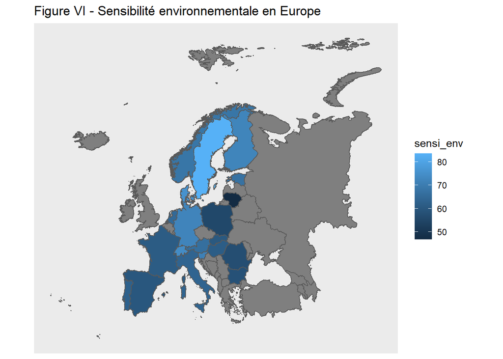

## Références théoriques à utiliser

*Courbe de Kuznets environnementale, Grossman (1993), Krueger (1995)* Corrélation entre développement d’une économie mesurée par le PIB/hab et la diminution de la pollution. Optimisme selon lequel l’amélioration des cond° de vie d’une pop° lui permet, après avoir subvenu à ses besoins primaires, d’améliorer la qualité de son mode de vie et de s’orienter vers des pd° moins polluantes.

*Données expérimentales, Anderson et al. (2008)* Une inégalité, lorsqu’elle est rendue publique, réduit la contribution à un bien public de tous les participants. C’est l’injustice perçue et non les inégalités en elles-mêmes qui réduisent le consentement à financer des biens publics et par conséquent la croissance.

*Inégalités et politique publiques, Rodrik (1999)* Les sociétés inégalitaires auraient plus de mal à mener des réformes nécessaires à la croissance. L’auteur prend l’exemple d’une économie confrontée à un choc externe. Les politiques publiques permettant de répondre aux chocs extérieurs ont des conséquences redistributives. La possibilité de les mettre en œuvre dépend grandement du climat social. S’il est mauvais et s’il s’avère impossible de mettre en place des réformes, l’économie peut être paralysé pendant des années.

[^1]: Thiery-Seror, P. (1996). La solidarité à travers les produits: l’achat-geste écologique. Actes du XIIème Congrès de l’AFM, Poitiers, 22-23 mai.
[^2]: http://jultika.oulu.fi/files/nbnfioulu-201312142043.pdf
[^3]: http://w.issp.org/fileadmin/user_upload/Module_development/Module_2020/Final_Source_Questionnaire/ISSP2020_final_sourcequestionnaire_corrected.pdf